# Week 9 - Homework - STAT 420, Summer 2021

Alejandro Pimentel (ap41)

**Defining some utility functions first. Click on the `Code` button to show it.**

```r
library(knitr)
library(kableExtra)
library(dplyr)
library(lmtest)

gen_kable <- function(table_data, add_row_names = TRUE, caption = "", col_names = c(), row_names = c()) {
  #f_data <- format_numerics(table_data)
  f_data <- table_data
  if(length(col_names) != 0){
    colnames(f_data) <- col_names
  }
  if(length(row_names) != 0){
    rownames(f_data) <- row_names
  }
  f_data %>%
  kable(., format = "html", row.names = add_row_names,
        caption = caption, escape = FALSE) %>%
    kable_styling(bootstrap_options = c("striped", "hover"),
                  full_width = F,
                  font_size = 14,
                  position = "center")
}

stat_decide <- function(p_f_value, alpha = 0.01) {
  ifelse(p_f_value < alpha, "Reject the Null Hypothesis", "FTR the Null Hypothesis")
}

diagnostics <- function(model, pcol = "grey", lcol = "dodgerblue",
                        alpha = 0.05, plotit = TRUE, testit = TRUE,
                        detailed = FALSE) {

  diags <- NULL
  if(testit) {
    p_val_st <- shapiro.test(model$residuals)$p.value
    p_val_bp <- bptest(model)$p.value
    hval <- hatvalues(model)
    cookd <- cooks.distance(model)
    diags <- list(
     "p_val" = p_val_st,
     "decision" = ifelse(p_val_st < alpha, "Reject", "Fail to Reject")
    )
    # Extending the function to add more diagnostics
    if(detailed) {
      diags$leverage <- list(
       "values" = hval,
       "large" = hval > 2 * mean(hval))
      diags$bptest <- list(
      "p_val" = p_val_bp,
      "decision" = ifelse(p_val_bp < alpha, "Reject", "Fail to Reject"))
      diags$cookd <- list(
       "values" = cookd,
       "influential" = cookd[cookd > 4 / length(cookd)])
    }
  }

  if(plotit) {
    par(mfrow = c(1, 2), bg="ghostwhite")
    plot(model$fitted.values, model$residuals,
         col = pcol, pch = 20,
         xlab = "Fitted", ylab = "Residuals",
         main = "Fitted vs Residuals")
    abline(h = 0, col = lcol, lwd = 2)
    qqnorm(model$residuals, main = "Normal Q-Q Plot",
           col = pcol)
    qqline(model$residuals, col = lcol, lwd = 2)
  }
  diags
}
```

## Exercise 1 (`longley` Macroeconomic Data)

The built-in dataset `longley` contains macroeconomic data for predicting employment. We will attempt to model the `Employed` variable.

```r
View(longley)
?longley
```

**(a)** What is the largest correlation between any pair of predictors in the dataset?

**Solution**

```r
# Get the correlation matrix and setting 0 in the diagonal
cor(longley)
```

```
##              GNP.deflator    GNP Unemployed Armed.Forces Population   Year
## GNP.deflator       1.0000 0.9916     0.6206       0.4647     0.9792 0.9911
## GNP                0.9916 1.0000     0.6043       0.4464     0.9911 0.9953
## Unemployed         0.6206 0.6043     1.0000      -0.1774     0.6866 0.6683
## Armed.Forces       0.4647 0.4464    -0.1774       1.0000     0.3644 0.4172
## Population         0.9792 0.9911     0.6866       0.3644     1.0000 0.9940
## Year               0.9911 0.9953     0.6683       0.4172     0.9940 1.0000
## Employed           0.9709 0.9836     0.5025       0.4573     0.9604 0.9713
##              Employed
## GNP.deflator   0.9709
## GNP            0.9836
## Unemployed     0.5025
## Armed.Forces   0.4573
## Population     0.9604
## Year           0.9713
## Employed       1.0000
```

```r
cor_0_on_diag <- cor(longley) * !diag(ncol(longley))

max_cor_val <- max(cor_0_on_diag)
pred_names <- row.names(which(cor_0_on_diag == max_cor_val, arr.ind = TRUE))
```

The largest correlation value is **0.9953**, between predictors **Year** and **GNP**.

**(b)** Fit a model with `Employed` as the response and the remaining variables as predictors. Calculate and report the variance inflation factor (VIF) for each of the predictors. Which variable has the largest VIF? Do any of the VIFs suggests multicollinearity?

**Solution**

```r
library(faraway)
mod_1b <- lm(Employed ~ ., data = longley)
(longley_vif <- vif(mod_1b))
```

```
## GNP.deflator          GNP   Unemployed Armed.Forces   Population         Year
##      135.532     1788.513       33.619        3.589      399.151      758.981
```

```r
max_vif <- longley_vif[longley_vif==max(longley_vif)]

large_vif_preds <- names(longley_vif > 5)
```

The predictor **GNP** has the largest `VIF` with a value of **1788.5135**.

**(c)** What proportion of the observed variation in `Population` is explained by a linear relationship with the other predictors?

**Solution**

```r
mod_1c <- lm(Population ~ . - Employed, data = longley)

popu_r2 <- summary(mod_1c)$r.squared
```

**99.7495%** of the variance in `Population` is explained by the other predictors. This aligns with the high `VIF` value for this predictor which is **399.151**.

**(d)** Calculate the partial correlation coefficient for `Population` and `Employed` **with the effects of the other predictors removed**.

**Solution**

```r
mod_1d_no_pop <- lm(Employed ~ . - Population, data = longley)

(pcres_emp_pop <- cor(mod_1c$residuals, mod_1d_no_pop$residuals))
```

```
## [1] -0.07514
```

The partial correlation coefficient for `Population` and `Employed` is **-0.0751**.

With such a small coefficient, adding `Population` to the model won’t help much.

**(e)** Fit a new model with `Employed` as the response and the predictors from the model in **(b)** that were significant. (Use $\alpha = 0.05$.) Calculate and report the variance inflation factor for each of the predictors. Which variable has the largest VIF? Do any of the VIFs suggest multicollinearity?

**Solution**

At $\alpha = 0.05$ the significant coefficients in model `mod_1b` are:

```r
mod_1b_coefs <- summary(mod_1b)$coef
alpha <- 0.05
# Select the coefficients that are lower than 0.05
(signif_coefs <- mod_1b_coefs[mod_1b_coefs[, 4] < alpha, ])
```

```
##                 Estimate Std. Error t value  Pr(>|t|)
## (Intercept)  -3482.25863 890.420384  -3.911 0.0035604
## Unemployed      -0.02020   0.004884  -4.136 0.0025351
## Armed.Forces    -0.01033   0.002143  -4.822 0.0009444
## Year             1.82915   0.455478   4.016 0.0030368
```

The `VIF` values for all predictors in this model are:

```r
mod_1e <- lm(Employed ~ Unemployed + Armed.Forces + Year, data = longley)

(longley_vif <- vif(mod_1e))
```

```
##   Unemployed Armed.Forces         Year
##        3.318        2.223        3.891
```

```r
max_vif <- longley_vif[longley_vif==max(longley_vif)]
```

The predictor Year has the largest `VIF` with a value of **3.8909**.

None of the predictors has a `VIF` value larger than `5` suggesting `no collinearity` issues.

**(f)** Use an $F$-test to compare the models in parts **(b)** and **(e)**. Report the following:

**Solution**

```r
anova_1f <- anova(mod_1e, mod_1b)
f_stat <- anova_1f[2, "F"]
p_val <- anova_1f[2, "Pr(>F)"]
df1 <- anova_1f[2, "Df"]
df2 <- anova_1f[2, "Res.Df"]
```

- The null hypothesis

$$H_0: \beta_{GNP.deflator} = \beta_{GNP} = \beta_{Population} = 0$$
- The test statistic

The value of the `F test statistic` is **1.7465**.

- The distribution of the test statistic under the null hypothesis

Under the `Null Hypothesis` the test statistic follows an **`F distribution`** with **3** and **9** degrees of freedom.

- The p-value

The p-value is 0.227.

- A decision

```r
(stat_decision <- stat_decide(p_val, alpha))
```

```
## [1] "FTR the Null Hypothesis"
```

With $\alpha = 0.05$ we **FTR the Null Hypothesis**.

- Which model you prefer, **(b)** or **(e)**

```r
(pref_mod <- mod_1e)
```

```
##
## Call:
## lm(formula = Employed ~ Unemployed + Armed.Forces + Year, data = longley)
##
## Coefficients:
##  (Intercept)    Unemployed  Armed.Forces          Year
##    -1.80e+03     -1.47e-02     -7.72e-03      9.56e-01
```

**(g)** Check the assumptions of the model chosen in part **(f)**. Do any assumptions appear to be violated?

**Solution**

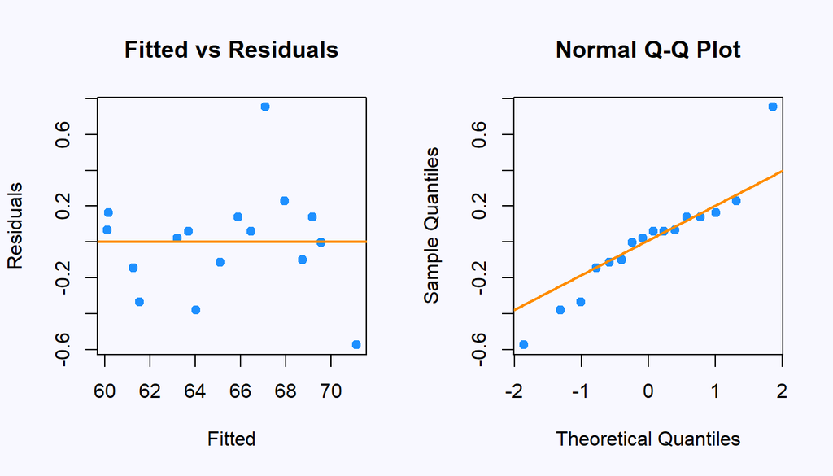

```r
par(mfrow = c(1, 2), bg="ghostwhite")
plot_fitted_resid(pref_mod)
plot_qq(pref_mod)
```

```r
diags <- diagnostics(pref_mod, detailed = TRUE, plotit = FALSE)
p_val_bp <- diags$bptest$p_val
p_val_sha <- diags$p_val
```

*Assumptions.*

Although the data set is very small I would consider that **the assumptions are not being violated**.

## Exercise 2 (`Credit` Data)

For this exercise, use the `Credit` data from the `ISLR` package. Use the following code to remove the `ID` variable which is not useful for modeling.

```r
library(ISLR)
data(Credit)
Credit = subset(Credit, select = -c(ID))
```

Use `?Credit` to learn about this dataset.

**(a)** Find a “good” model for `balance` using the available predictors. Use any methods seen in class except transformations of the response. The model should:

- Reach a LOOCV-RMSE below `140`
- Obtain an adjusted $R^2$ above `0.90`
- Fail to reject the Breusch-Pagan test with an $\alpha$ of $0.01$
- Use fewer than 10 $\beta$ parameters

Store your model in a variable called `mod_a`. Run the two given chunks to verify your model meets the requested criteria. If you cannot find a model that meets all criteria, partial credit will be given for meeting at least some of the criteria.

```r
library(lmtest)

get_bp_decision = function(model, alpha) {
  decide = unname(bptest(model)$p.value < alpha)
  ifelse(decide, "Reject", "Fail to Reject")
}

get_sw_decision = function(model, alpha) {
  decide = unname(shapiro.test(resid(model))$p.value < alpha)
  ifelse(decide, "Reject", "Fail to Reject")
}

get_num_params = function(model) {
  length(coef(model))
}

get_loocv_rmse = function(model) {
  sqrt(mean((resid(model) / (1 - hatvalues(model))) ^ 2))
}

get_adj_r2 = function(model) {
  summary(model)$adj.r.squared
}
```

**Solution**

One immediate detail to notice with an `histogram` for the predictor `Income` is that a `log` transformation might be beneficial.

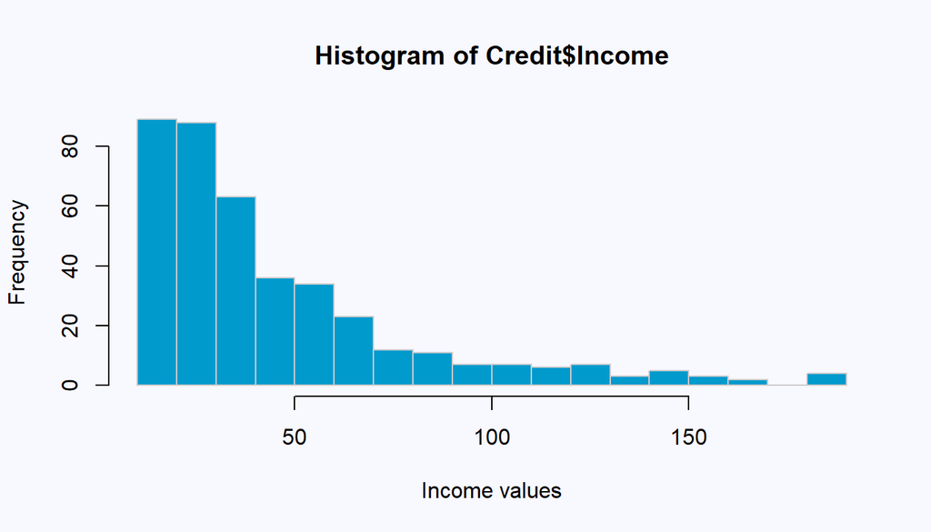

```r
par(mfrow = c(1, 1), bg="ghostwhite")
hist(Credit$Income, breaks = 20,
     xlab = "Income values",
     border = "gray80",
     col = "deepskyblue3"
     )
```

Start with an additive model that uses `log(Income)`. Then find a smaller model using `backward search`.

```r
(add_balance_mod <- lm(Balance ~ . - Income + log(Income)
                       , data = Credit))
```

```
##
## Call:
## lm(formula = Balance ~ . - Income + log(Income), data = Credit)
##
## Coefficients:
##        (Intercept)               Limit              Rating               Cards
##            448.932               0.225               0.205              19.271
##                Age           Education        GenderFemale          StudentYes
##             -1.009              -2.088              -1.232             418.081
##         MarriedYes      EthnicityAsian  EthnicityCaucasian         log(Income)
##            -17.706              11.631              20.356            -304.662
```

```r
(small_balance_mod <- step(add_balance_mod, direction = "backward"
               , trace = 0, k = log(nrow(Credit))))
```

```
##
## Call:
## lm(formula = Balance ~ Limit + Cards + Age + Student + log(Income),
##     data = Credit)
##
## Coefficients:
## (Intercept)        Limit        Cards          Age   StudentYes  log(Income)
##     424.103        0.239       20.578       -0.993      418.439     -303.805
```

After observing how adding transformations to the predictors on `small_balance_mod` affected the `Fitted vs Residuals` plot, I found the following model.

```r
mod_a <- lm(Balance ~ Limit
         + poly(Cards, degree = 3)
         + poly(Age, degree = 2)
         + Student + log(Income)
         , data = Credit)
```

```r
get_loocv_rmse(mod_a)
```

```
## [1] 131.1
```

```r
get_adj_r2(mod_a)
```

```
## [1] 0.9206
```

```r
get_bp_decision(mod_a, alpha = 0.01)
```

```
## [1] "Fail to Reject"
```

```r
get_num_params(mod_a)
```

```
## [1] 9
```

**(b)** Find another “good” model for `balance` using the available predictors. Use any methods seen in class except transformations of the response. The model should:

- Reach a LOOCV-RMSE below `130`
- Obtain an adjusted $R^2$ above `0.85`
- Fail to reject the Shapiro-Wilk test with an $\alpha$ of $0.01$
- Use fewer than 25 $\beta$ parameters

Store your model in a variable called `mod_b`. Run the two given chunks to verify your model meets the requested criteria. If you cannot find a model that meets all criteria, partial credit will be given for meeting at least some of the criteria.

```r
library(lmtest)

get_bp_decision = function(model, alpha) {
  decide = unname(bptest(model)$p.value < alpha)
  ifelse(decide, "Reject", "Fail to Reject")
}

get_sw_decision = function(model, alpha) {
  decide = unname(shapiro.test(resid(model))$p.value < alpha)
  ifelse(decide, "Reject", "Fail to Reject")
}

get_num_params = function(model) {
  length(coef(model))
}

get_loocv_rmse = function(model) {
  sqrt(mean((resid(model) / (1 - hatvalues(model))) ^ 2))
}

get_adj_r2 = function(model) {
  summary(model)$adj.r.squared
}
```

**Solution**

I start with big model using 2-way

```r
mod_b_big <- lm(Balance ~ (Limit +
            + Cards
            + Age
            + Student
            + Married
            + Education
            + log(Income)) ^ 2
            , data = Credit)

mod_b <- step(mod_b_big,
                direction = "backward"
               , trace = 0)
```

```r
get_loocv_rmse(mod_b)
```

```
## [1] 118.3
```

```r
get_adj_r2(mod_b)
```

```
## [1] 0.9377
```

```r
get_sw_decision(mod_b, alpha = 0.01)
```

```
## [1] "Fail to Reject"
```

```r
get_num_params(mod_b)
```

```
## [1] 18
```

## Exercise 3 (`Sacramento` Housing Data)

Instead of using the `city` or `zip` variables that exist in the dataset, we will simply create a variable (`limits`) indicating whether or not a house is technically within the city limits of Sacramento. (We do this because they would both be factor variables with a **large** number of levels. This is a choice that is made due to laziness, not necessarily because it is justified. Think about what issues these variables might cause.)

Use `?Sacramento` to learn more about this dataset.

A plot of longitude versus latitude gives us a sense of where the city limits are.

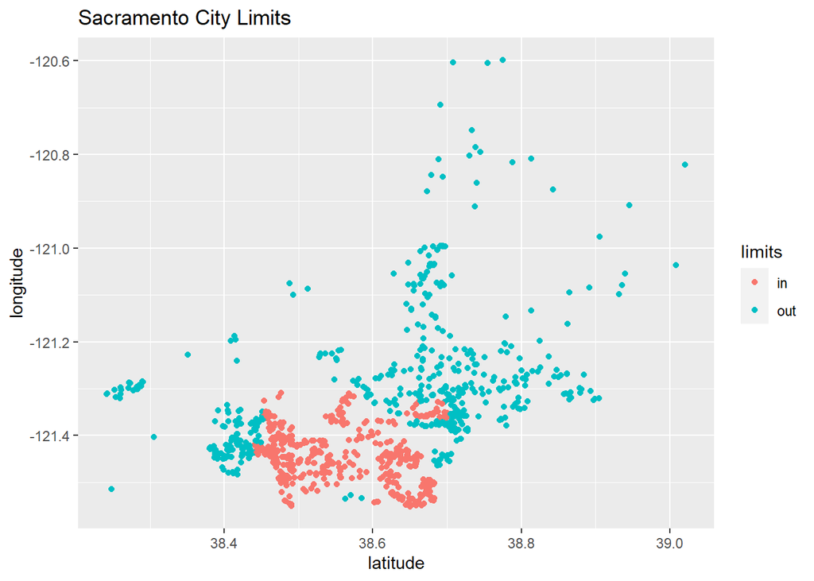

```r
qplot(y = longitude, x = latitude, data = sac_data,
      col = limits, main = "Sacramento City Limits ")
```

```r
set.seed(420)
sac_trn_idx  = sample(nrow(sac_data), size = trunc(0.80 * nrow(sac_data)))
sac_trn_data = sac_data[sac_trn_idx, ]
sac_tst_data = sac_data[-sac_trn_idx, ]
```

The training data should be used for all model fitting. Our goal is to find a model that is useful for predicting home prices.

**(a)** Find a “good” model for `price`. Use any methods seen in class. The model should reach a LOOCV-RMSE below 77,500 in the training data. Do not use any transformations of the response variable.

**Solution**

```r
#pairs(sac_trn_data)
big_price_mod <- lm(price ~ (
                     + sqft + I(sqft^2)
                     + beds
                     + baths
                     + latitude
                     + longitude
                     + limits
                     + type
                     ) ^ 2
                       , data = sac_trn_data)

# Using BIC backward search
bic_price_mod <- step(big_price_mod
                ,direction = "backward"
                ,k = log(nrow(sac_trn_data))
                ,trace = 0)

get_loocv_rmse(bic_price_mod)
```

```
## [1] 75713
```

**(b)** Is a model that achieves a LOOCV-RMSE below 77,500 useful in this case? That is, is an average error of 77,500 low enough when predicting home prices? To further investigate, use the held-out test data and your model from part **(a)** to do two things:

**Solution**

- Calculate the average percent error:
  $$\frac{1}{n}\sum_i\frac{|\text{predicted}_i - \text{actual}_i|}{\text{predicted}_i} \times 100$$

```r
predicted <- predict(bic_price_mod, newdata = sac_tst_data)
actual <- sac_tst_data$price

(avg_perct_error <- mean(abs(predicted - actual) / predicted) * 100)
```

```
## [1] 24.36
```

Using the test data, percentage of prediction errors made by the model is **24.3611 %**.

- Plot the predicted versus the actual values and add the line $y = x$.

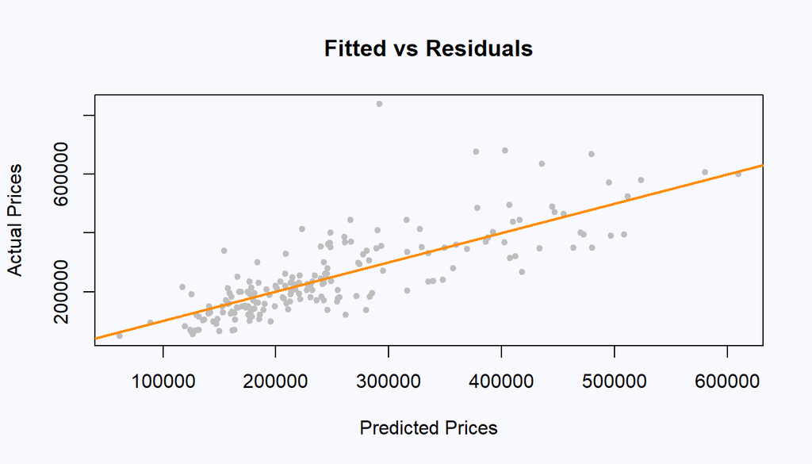

```r
par(mfrow = c(1, 1), bg="ghostwhite")
plot(predicted, actual,
     col = "grey", pch = 20,
     xlab = "Predicted Prices", ylab = "Actual Prices",
     main = "Fitted vs Residuals")
abline(0, 1, col = "darkorange", lwd = 2)
```

*Based on all of this information, argue whether or not this model is useful.*

We can see from the graph that most predictions are either `overestimating` or `underestimating` sometimes for as much as `hundreds of thousands of dollars`. This is due to having a relatively high `Average Percentage Error`.

It seems from the graph that the `model` is doing better with prices under `300,000 USD`, while the errors seem to be larger with higher prices. Perhaps this is due to having more observation in the lower range of prices.

I would consider the `model` useful, but I would also have some reservations about it.

Now, from a more subjective/practical point of view.

If I am buyer in the market, predictions like this are really no that informative. That said, the results of the model can be `useful` to give a very general idea of what prices I am looking at as a buyer. But the model is definitely `not useful` to make final decisions by in itself, perhaps almost any model is.

As a researcher, the model is `useful` to realize that we are making a fairly decent approximation of `price` prediction, from here, we should consider options to improve it.

## Exercise 4 (Does It Work?)

In this exercise, we will investigate how well backwards AIC and BIC actually perform. For either to be “working” correctly, they should result in a low number of both **false positives** and **false negatives**. In model selection,

- **False Positive**, FP: Incorrectly including a variable in the model. Including a *non-significant* variable
- **False Negative**, FN: Incorrectly excluding a variable in the model. Excluding a *significant* variable

Consider the **true** model

$$Y = \beta_0 + \beta_1 x_1 + \beta_2 x_2 + \beta_3 x_3 + \beta_4 x_4 + \beta_5 x_5 + \beta_6 x_6 + \beta_7 x_7 + \beta_8 x_8 + \beta_9 x_9 + \beta_{10} x_{10} + \epsilon$$

where $\epsilon \sim N(0, \sigma^2 = 4)$. The true values of the $\beta$ parameters are given in the `R` code below.

```r
beta_0  = 1
beta_1  = -1
beta_2  = 2
beta_3  = -2
beta_4  = 1
beta_5  = 1
beta_6  = 0
beta_7  = 0
beta_8  = 0
beta_9  = 0
beta_10 = 0
sigma = 2
```

Then, as we have specified them, some variables are significant, and some are not. We store their names in `R` variables for use later.

```r
not_sig  = c("x_6", "x_7", "x_8", "x_9", "x_10")
signif = c("x_1", "x_2", "x_3", "x_4", "x_5")
```

We now simulate values for these `x` variables, which we will use throughout part **(a)**.

```r
set.seed(420)
n = 100
x_1  = runif(n, 0, 10)
x_2  = runif(n, 0, 10)
x_3  = runif(n, 0, 10)
x_4  = runif(n, 0, 10)
x_5  = runif(n, 0, 10)
x_6  = runif(n, 0, 10)
x_7  = runif(n, 0, 10)
x_8  = runif(n, 0, 10)
x_9  = runif(n, 0, 10)
x_10 = runif(n, 0, 10)
```

We then combine these into a data frame and simulate `y` according to the true model.

```r
sim_data_1 = data.frame(x_1, x_2, x_3, x_4, x_5, x_6, x_7, x_8, x_9, x_10,
  y = beta_0 + beta_1 * x_1 + beta_2 * x_2 + beta_3 * x_3 + beta_4 * x_4 +
      beta_5 * x_5 + rnorm(n, 0 , sigma)
)
```

We do a quick check to make sure everything looks correct.

```r
head(sim_data_1)
```

```
##     x_1   x_2    x_3    x_4    x_5   x_6    x_7    x_8   x_9   x_10       y
## 1 6.055 4.088 8.7894 1.8180 0.8198 8.146 9.7305 9.6673 6.915 4.5523 -11.627
## 2 9.703 3.634 5.0768 5.5784 6.3193 6.033 3.2301 2.6707 2.214 0.4861  -0.147
## 3 1.745 3.899 0.5431 4.5068 1.0834 3.427 3.2223 5.2746 8.242 7.2310  15.145
## 4 4.758 5.315 7.6257 0.1287 9.4057 6.168 0.2472 6.5325 2.102 4.5814   2.404
## 5 7.245 7.225 9.5763 3.0398 0.4194 5.937 9.2169 4.6228 2.527 9.2349  -7.910
## 6 8.761 5.177 1.7983 0.5949 9.2944 9.392 1.0017 0.4476 5.508 5.9687   9.764
```

Now, we fit an incorrect model.

```r
fit = lm(y ~ x_1 + x_2 + x_6 + x_7, data = sim_data_1)
coef(fit)
```

```
## (Intercept)         x_1         x_2         x_6         x_7
##     -1.3758     -0.3572      2.1040      0.1344     -0.3367
```

Notice, we have coefficients for `x_1`, `x_2`, `x_6`, and `x_7`. This means that `x_6` and `x_7` are false positives, while `x_3`, `x_4`, and `x_5` are false negatives.

To detect the false negatives, use:

```r
# which are false negatives?
!(signif %in% names(coef(fit)))
```

```
## [1] FALSE FALSE  TRUE  TRUE  TRUE
```

To detect the false positives, use:

```r
# which are false positives?
names(coef(fit)) %in% not_sig
```

```
## [1] FALSE FALSE FALSE  TRUE  TRUE
```

Note that in both cases, you could `sum()` the result to obtain the number of false negatives or positives.

**(a)** Set a seed equal to your birthday; then, using the given data for each `x` variable above in `sim_data_1`, simulate the response variable `y` 300 times. Each time,

- Fit an additive model using each of the `x` variables.
- Perform variable selection using backwards AIC.
- Perform variable selection using backwards BIC.
- Calculate and store the number of false negatives for the models chosen by AIC and BIC.
- Calculate and store the number of false positives for the models chosen by AIC and BIC.

Calculate the rate of false positives and negatives for both AIC and BIC. Compare the rates between the two methods. Arrange your results in a well formatted table.

**solution**

Initialize some variables.

```r
birthday = 19820426
set.seed(birthday)

X <- sim_data_1[, 1:10]
betas <- c(1, -1, 2, -2, 1, 1, rep(0, 5))
num_sims <- 300
```

Define 2 functions to help us during the simulation:

- First on to simulate data and train a model based on that.
- Second counts the `False Positive and Negative` picks of predictors made by the `step` function.

```r
generate_mlr_data <- function(X, betas, sigma = 2) {
  n <- nrow(X)
  epsilon <- rnorm(n = n, mean = 0, sd = sigma)
  X_full <- as.matrix(cbind(1, X))
  X$y <- (X_full %*% betas) + epsilon
  as.data.frame(X)

}

# It's weird that I have to keep sim_data in the scope where
# I call step(), otherwise it throws an error... go figure.
get_fn_fp <- function(model, sim_data) {
  aic_coef_names <- names(step(model, direction = "backward",
             trace = 0)$coef)

  bic_coef_names <- names(step(model, direction = "backward",
           k = log(n), trace = 0)$coef)

  list(
    aic_fn = sum(!(signif %in% aic_coef_names)),
    aic_fp = sum(aic_coef_names %in% not_sig),
    bic_fn = sum(!(signif %in% bic_coef_names)),
    bic_fp = sum(bic_coef_names %in% not_sig)
  )
}
```

We define a function that executes the simulation. Then we call it to start the simulation.

```r
run_sim <- function(X, betas, sigma) {
  fn_count <- c(0, 0)
  fp_count <- c(0, 0)

  for(i in 1:num_sims) {
    sim_data <- generate_mlr_data(X, matrix(betas), sigma)
    sim_model <- lm(y ~ ., data = sim_data)
    stats <- get_fn_fp(sim_model, sim_data)

    fn_count[1] <- stats$aic_fn + fn_count[1]
    fn_count[2] <- stats$bic_fn + fn_count[2]

    fp_count[1] <- stats$aic_fp + fp_count[1]
    fp_count[2] <- stats$bic_fp + fp_count[2]
  }

  list(fn = fn_count, fp = fp_count)
}

result_sim <- run_sim(X, betas, sigma)
```

The following table shows the results for the simulation.

```r
tdata <- data.frame(
  "fn" = result_sim$fn,
  "fp" = result_sim$fp,
  "fn_rate" = result_sim$fn / num_sims,
  "fp_rate" = result_sim$fp / num_sims
)

gen_kable(tdata, row_names = c("AIC", "BIC"),
          col_names = c("False Negatives", "False Positives",
                        "FN Rate", "FP Rate"),
          caption = "Predictor picks (Backward Search)")
```

Predictor picks (Backward Search)

|  | False Negatives | False Positives | FN Rate | FP Rate |
| --- | --- | --- | --- | --- |
| AIC | 0 | 247 | 0 | 0.8233 |
| BIC | 0 | 73 | 0 | 0.2433 |

**(b)** Set a seed equal to your birthday; then, using the given data for each `x` variable below in `sim_data_2`, simulate the response variable `y` 300 times. Each time,

- Fit an additive model using each of the `x` variables.
- Perform variable selection using backwards AIC.
- Perform variable selection using backwards BIC.
- Calculate and store the number of false negatives for the models chosen by AIC and BIC.
- Calculate and store the number of false positives for the models chosen by AIC and BIC.

Calculate the rate of false positives and negatives for both AIC and BIC. Compare the rates between the two methods. Arrange your results in a well formatted table. Also compare to your answers in part **(a)** and suggest a reason for any differences.

```r
set.seed(94)
x_1  = runif(n, 0, 10)
x_2  = runif(n, 0, 10)
x_3  = runif(n, 0, 10)
x_4  = runif(n, 0, 10)
x_5  = runif(n, 0, 10)
x_6  = runif(n, 0, 10)
x_7  = runif(n, 0, 10)
x_8  = x_1 + rnorm(n, 0, 0.1)
x_9  = x_1 + rnorm(n, 0, 0.1)
x_10 = x_2 + rnorm(n, 0, 0.1)

sim_data_2 = data.frame(x_1, x_2, x_3, x_4, x_5, x_6, x_7, x_8, x_9, x_10,
  y = beta_0 + beta_1 * x_1 + beta_2 * x_2 + beta_3 * x_3 + beta_4 * x_4 +
      beta_5 * x_5 + rnorm(n, 0 , sigma)
)
```

**Solution**

Initialize some variables.

```r
birthday = 19820426
set.seed(birthday)

X <- sim_data_2[, 1:10]
betas <- c(1, -1, 2, -2, 1, 1, rep(0, 5))
num_sims <- 300
```

Start the simulation and show the results.

```r
result_sim <- run_sim(X, betas, sigma)

tdata <- data.frame(
  "fn" = result_sim$fn,
  "fp" = result_sim$fp,
  "fn_rate" = result_sim$fn / num_sims,
  "fp_rate" = result_sim$fp / num_sims
)

gen_kable(tdata, row_names = c("AIC", "BIC"),
          col_names = c("False Negatives", "False Positives",
                        "FN Rate", "FP Rate"),
          caption = "Predictor picks (Backward Search)")
```

Predictor picks (Backward Search)

|  | False Negatives | False Positives | FN Rate | FP Rate |
| --- | --- | --- | --- | --- |
| AIC | 244 | 481 | 0.8133 | 1.603 |
| BIC | 264 | 328 | 0.8800 | 1.093 |

In this case the model `search` is expected to have **more** `False Positive` and `False Negative` errors since we established in the data definition that *2 of the known significant predictors*, namely $x_1$ and $x_2$, have collinearity issues with $x_8$, $x_9$ and $x_{10}$.

We can verify that as shown below:

```r
cor_matrix <- round(cor(X), 4)
```

- $x_1$ Collinearity with $x_8$ = 0.9995
- $x_1$ Collinearity with $x_9$ = 0.9994
- $x_2$ Collinearity with $x_10$ = 0.9995

Under these conditions, the `step` function can for instance select $x_8$ instead of $x_1$. This behavior might not have a big effect in `prediction` but it will increase the `variance` of our estimated $\hat\beta$ parameters.